# DATA 606 Final Exam

Kyle Gilde

May 20, 2017

```
##
## prettydoc TRUE
```

# Part I

1. A student is gathering data on the driving experiences of other college students. A description of the data car color is presented below. Which of the variables are quantitative and discrete?

**b. daysDrive**

**a. mean = 3.3, median = 3.5**

3. A researcher wants to determine if a new treatment is effective for reducing Ebola related fever. What type of study should be conducted in order to establish that the treatment does indeed cause improvement in Ebola patients?

**a. Randomly assign Ebola patients to one of two groups, either the treatment or placebo group, and then compare the fever of the two groups.**

4. A study is designed to test whether there is a relationship between natural hair color (brunette, blond, red) and eye color (blue, green, brown). If a large ??2 test statistic is obtained, this suggests that:

**c. there is an association between natural hair color and eye color.**

5. A researcher studying how monkeys remember is interested in examining the distribution of the score on a standard memory task. The researcher wants to produce a boxplot to examine this distribution. Below are summary statistics from the memory task. What values should the researcher use to determine if a particular score is a potential outlier in the boxplot?

min Q1 median Q3 max mean sd n 26 37 45 49.8 65 44.4 8.4 50

**b. 17.8 and 69.0**

```r
Q1 <- 37
Q3 <- 49.8

IQR <- Q3 - Q1
IQR1.5 <- 1.5 * IQR

Q1 - IQR1.5
```

```
## [1] 17.8
```

```r
Q3 + IQR1.5
```

```
## [1] 69
```

6. The _ are resistant to outliers, whereas the __ are not.

**d. median and interquartile range; mean and standard deviation**

**Both figures appear to be normally distributed. However, the spread of the sampling distribution in Figure B is much less than the spread of the distribution of the observed variable in Figure A.**

2. Explain why the means of these two distributions are similar but the standard deviations are not (2 pts).

**Since the sample size is at least 30, the mean of the sampling distribution in Figure B will closely approximate the mean of the population in Figure A.**

**However, because the sampling distribution is composed of sample means from the observed variable, i.e. the population, its spread will be less than the spread of the population distribution. The standard deviation of a sampling distribution is called the standard error and is calculated by dividing the population standard deviation by the square root of the sample size. Therefore, the standard error will always be less than the population standard deviation.**

3. What is the statistical principal that describes this phenomenon (2 pts)?

**Central Limit Theorem**

# Part II

Consider the four datasets, each with two columns (x and y), provided below.

```r
options(digits = 2)

data1 <- data.frame(x = c(10, 8, 13, 9, 11, 14, 6, 4, 12, 7, 5), y = c(8.04,
    6.95, 7.58, 8.81, 8.33, 9.96, 7.24, 4.26, 10.84, 4.82, 5.68))
data2 <- data.frame(x = c(10, 8, 13, 9, 11, 14, 6, 4, 12, 7, 5), y = c(9.14,
    8.14, 8.74, 8.77, 9.26, 8.1, 6.13, 3.1, 9.13, 7.26, 4.74))
data3 <- data.frame(x = c(10, 8, 13, 9, 11, 14, 6, 4, 12, 7, 5), y = c(7.46,
    6.77, 12.74, 7.11, 7.81, 8.84, 6.08, 5.39, 8.15, 6.42, 5.73))
data4 <- data.frame(x = c(8, 8, 8, 8, 8, 8, 8, 19, 8, 8, 8), y = c(6.58, 5.76,
    7.71, 8.84, 8.47, 7.04, 5.25, 12.5, 5.56, 7.91, 6.89))

# all_dfs <- c(data1, data2, data3, data4)
all_dfs <- c("data1", "data2", "data3", "data4")
```

### For each column, calculate (to two decimal places):

1. The mean (for x and y separately; 1 pt).

```r
for (i in all_dfs) {
    my_df <- get(i)
    print(i)
    print(sapply(my_df, function(x) round(mean(x), 2)))
}
```

```
## [1] "data1"
##   x   y
## 9.0 7.5
## [1] "data2"
##   x   y
## 9.0 7.5
## [1] "data3"
##   x   y
## 9.0 7.5
## [1] "data4"
##   x   y
## 9.0 7.5
```

2. The median (for x and y separately; 1 pt).

```r
for (i in all_dfs) {
    my_df <- get(i)
    print(i)
    print(sapply(my_df, function(x) round(median(x), 2)))
}
```

```
## [1] "data1"
##    x    y
## 9.00 7.58
## [1] "data2"
##    x    y
## 9.00 8.14
## [1] "data3"
##    x    y
## 9.00 7.11
## [1] "data4"
##    x    y
## 8.00 7.04
```

3. The standard deviation (for x and y separately; 1 pt).

```r
for (i in all_dfs) {
    my_df <- get(i)
    print(i)
    print(sapply(my_df, function(x) round(sd(x), 2)))
}
```

```
## [1] "data1"
##    x    y
## 3.32 2.03
## [1] "data2"
##    x    y
## 3.32 2.03
## [1] "data3"
##    x    y
## 3.32 2.03
## [1] "data4"
##    x    y
## 3.32 2.03
```

### For each x and y pair, calculate (also to two decimal places; 1 pt):

4. The correlation (1 pt).

```r
for (i in all_dfs) {
    my_df <- get(i)
    print(i)
    print(round(cor(my_df), 2))
}
```

```
## [1] "data1"
##      x    y
## x 1.00 0.82
## y 0.82 1.00
## [1] "data2"
##      x    y
## x 1.00 0.82
## y 0.82 1.00
## [1] "data3"
##      x    y
## x 1.00 0.82
## y 0.82 1.00
## [1] "data4"
##      x    y
## x 1.00 0.82
## y 0.82 1.00
```

5. Linear regression equation (2 pts).

```r
m_list <- c()

for (i in all_dfs) {
    i_df <- get(i)
    i_lm <- lm(y ~ x, i_df)
    new_var <- paste0("m_", i)
    assign(new_var, i_lm)
    m_list <- c(m_list, new_var)
    intercept <- round(coef(i_lm)[1], 2)
    slope <- round(coef(i_lm)[2], 2)
    print(i)
    print(paste0("y-hat = ", slope, " * x + ", intercept))
}
```

```
## [1] "data1"
## [1] "y-hat = 0.5 * x + 3"
## [1] "data2"
## [1] "y-hat = 0.5 * x + 3"
## [1] "data3"
## [1] "y-hat = 0.5 * x + 3"
## [1] "data4"
## [1] "y-hat = 0.5 * x + 3"
```

6. R-Squared (2 pts).

```r
sapply(m_list, function(x) round(summary(get(x))$r.squared, 2))
```

```
## m_data1 m_data2 m_data3 m_data4
##    0.67    0.67    0.67    0.67
```

For each pair, is it appropriate to estimate a linear regression model? Why or why not? Be specific as to why for each pair and include appropriate plots! (4 pts)

**We were not given any information on how or in what order the data were collected, so we cannot evaluate the Independence Condition for the 4 models.**

```
## [1] "Check conditions for data1"
```

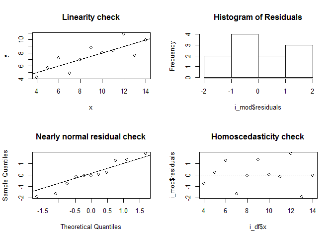

```
## [1] "Check conditions for data2"
```

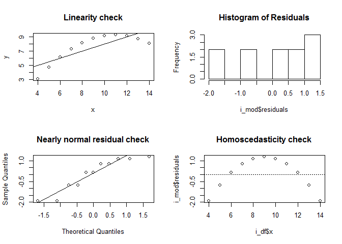

```
## [1] "Check conditions for data3"
```

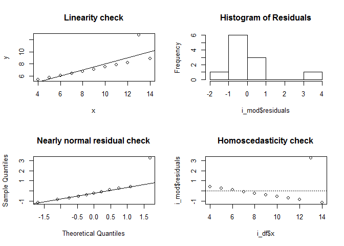

```
## [1] "Check conditions for data4"
```

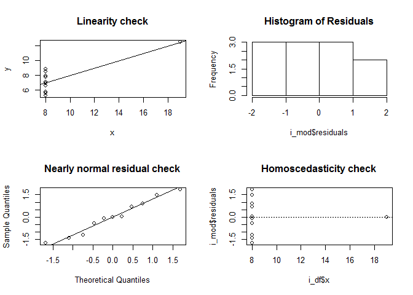

```r
op <- par(mfrow = c(2, 2))
for (i in 1:4) {
    i_df_name <- all_dfs[i]
    i_df <- get(i_df_name)
    i_mod <- get(m_list[i])
    print(paste("Check conditions for", i_df_name))

    # linearity plot
    plot(y ~ x, i_df, main = "Linearity check")
    abline(i_mod)

    # residual normality check
    hist(i_mod$residuals, main = "Histogram of Residuals")
    qqnorm(i_mod$residuals, main = "Nearly normal residual check")
    qqline(i_mod$residuals)

    # Homoscedasticity check
    plot(i_mod$residuals ~ i_df$x, main = "Homoscedasticity check")
    abline(h = 0, lty = 3)
}
```

```r
par(op)
```

Explain why it is important to include appropriate visualizations when analyzing data. Include any visualization(s) you create. (2 pts)

**A linear model is only valid if the necessary conditions have been met, and creating visualizations is one way to check for linearity, nearly normal residuals, homoscedasticity, and sometimes even independence when the data collection order is provided. Please see the plots above.**